# **Importing Necessary Libraries**

```python
import pandas as pd
import seaborn as sns
import matplotlib.pyplot as plt
import time
from scipy.stats import f_oneway
import statsmodels.api as sm
from statsmodels.formula.api import ols
from scipy.stats import linregress
import numpy as np
from scipy.stats import spearmanr
from scipy.stats import kruskal
import shap

import warnings
warnings.filterwarnings("ignore")

# Plotting style
sns.set(style="whitegrid")
plt.rcParams["figure.figsize"] = (12, 6)

%matplotlib inline
```

# **Importing Dataset**

```python
df = pd.read_csv("FMCG_2022_2024.csv")
df
```

|  | date | sku | brand | segment | category | channel | region | pack_type | price_unit | promotion_flag | delivery_days | stock_available | delivered_qty | units_sold |
| --- | --- | --- | --- | --- | --- | --- | --- | --- | --- | --- | --- | --- | --- | --- |
| 0 | 2022-01-21 | MI-006 | MiBrand1 | Milk-Seg3 | Milk | Retail | PL-Central | Multipack | 2.38 | 0 | 1 | 141 | 128 | 9 |
| 1 | 2022-01-21 | MI-006 | MiBrand1 | Milk-Seg3 | Milk | Retail | PL-North | Single | 1.55 | 1 | 3 | 0 | 129 | 0 |
| 2 | 2022-01-21 | MI-006 | MiBrand1 | Milk-Seg3 | Milk | Retail | PL-South | Carton | 4.00 | 0 | 5 | 118 | 161 | 8 |
| 3 | 2022-01-21 | MI-006 | MiBrand1 | Milk-Seg3 | Milk | Discount | PL-Central | Single | 5.16 | 0 | 2 | 81 | 114 | 7 |
| 4 | 2022-01-21 | MI-006 | MiBrand1 | Milk-Seg3 | Milk | Discount | PL-North | Single | 7.66 | 0 | 4 | 148 | 204 | 12 |
| ... | ... | ... | ... | ... | ... | ... | ... | ... | ... | ... | ... | ... | ... | ... |
| 190752 | 2024-12-31 | SN-030 | SnBrand2 | SnackBar-Seg1 | SnackBar | Discount | PL-North | Single | 2.55 | 0 | 2 | 190 | 163 | 25 |
| 190753 | 2024-12-31 | SN-030 | SnBrand2 | SnackBar-Seg1 | SnackBar | Discount | PL-South | Single | 6.01 | 0 | 5 | 141 | 131 | 19 |
| 190754 | 2024-12-31 | SN-030 | SnBrand2 | SnackBar-Seg1 | SnackBar | E-commerce | PL-Central | Single | 3.45 | 0 | 5 | 0 | 132 | 0 |
| 190755 | 2024-12-31 | SN-030 | SnBrand2 | SnackBar-Seg1 | SnackBar | E-commerce | PL-North | Multipack | 1.93 | 1 | 2 | 211 | 201 | 40 |
| 190756 | 2024-12-31 | SN-030 | SnBrand2 | SnackBar-Seg1 | SnackBar | E-commerce | PL-South | Single | 1.91 | 0 | 5 | 82 | 125 | 8 |

190757 rows × 14 columns

# **Data Cleaning**

### 1. Missing Values Check

```python
df.isnull().sum()
```

```
date               0
sku                0
brand              0
segment            0
category           0
channel            0
region             0
pack_type          0
price_unit         0
promotion_flag     0
delivery_days      0
stock_available    0
delivered_qty      0
units_sold         0
dtype: int64
```

### 2. Data Type Conversion

```python
df.info()
```

```
<class 'pandas.core.frame.DataFrame'>
RangeIndex: 190757 entries, 0 to 190756
Data columns (total 14 columns):
 #   Column           Non-Null Count   Dtype
---  ------           --------------   -----
 0   date             190757 non-null  object
 1   sku              190757 non-null  object
 2   brand            190757 non-null  object
 3   segment          190757 non-null  object
 4   category         190757 non-null  object
 5   channel          190757 non-null  object
 6   region           190757 non-null  object
 7   pack_type        190757 non-null  object
 8   price_unit       190757 non-null  float64
 9   promotion_flag   190757 non-null  int64
 10  delivery_days    190757 non-null  int64
 11  stock_available  190757 non-null  int64
 12  delivered_qty    190757 non-null  int64
 13  units_sold       190757 non-null  int64
dtypes: float64(1), int64(5), object(8)
memory usage: 20.4+ MB
```

```python
# Convert datatype of Date column into Date format
df['date'] = pd.to_datetime(df['date'])
```

```python
# checking if data is converted
df.info()
```

```
<class 'pandas.core.frame.DataFrame'>
RangeIndex: 190757 entries, 0 to 190756
Data columns (total 14 columns):
 #   Column           Non-Null Count   Dtype
---  ------           --------------   -----
 0   date             190757 non-null  datetime64[ns]
 1   sku              190757 non-null  object
 2   brand            190757 non-null  object
 3   segment          190757 non-null  object
 4   category         190757 non-null  object
 5   channel          190757 non-null  object
 6   region           190757 non-null  object
 7   pack_type        190757 non-null  object
 8   price_unit       190757 non-null  float64
 9   promotion_flag   190757 non-null  int64
 10  delivery_days    190757 non-null  int64
 11  stock_available  190757 non-null  int64
 12  delivered_qty    190757 non-null  int64
 13  units_sold       190757 non-null  int64
dtypes: datetime64[ns](1), float64(1), int64(5), object(7)
memory usage: 20.4+ MB
```

### 3. Invalid Values Removal

```python
# Showing the Negative values
df.select_dtypes(include=[np.number]).min()
```

```
price_unit          1.5
promotion_flag      0.0
delivery_days       1.0
stock_available   -12.0
delivered_qty     -11.0
units_sold        -25.0
dtype: float64
```

```python
negative_counts = (df.select_dtypes(include='number') < 0).sum()

print("Count of negative values per column:")
print(negative_counts)
```

```
Count of negative values per column:
price_unit         0
promotion_flag     0
delivery_days      0
stock_available    3
delivered_qty      3
units_sold         3
dtype: int64
```

```python
# Removing the Negative Rows
df = df[df['stock_available'] >= 0]
```

```python
df.shape
```

```
(190754, 14)
```

### 4. Feature Engineering

```python
df['Revenue'] = df['units_sold'] * df['price_unit']
df['Year'] = df['date'].dt.year
df['Month'] = df['date'].dt.month
df['Day'] = df['date'].dt.day
```

```python
# Deviding Price unit into 3 levels

df['price_range'] = pd.qcut(
    df['price_unit'],
    q=3,
    labels=['Low', 'Medium', 'High']
)

price_sales = df.groupby('price_range')['units_sold'].mean()
price_sales
```

```
price_range
Low       19.956213
Medium    19.871058
High      19.933186
Name: units_sold, dtype: float64
```

```python
# Separate units_sold by price group
Low = df[df['price_range'] == 'Low']['units_sold']
Medium = df[df['price_range'] == 'Medium']['units_sold']
High = df[df['price_range'] == 'High']['units_sold']
```

```python
# Stock-to-Sales Ratio
df['stock_to_sales_ratio'] = df['stock_available'] / df['units_sold'].replace(0, 1)
# Inventory turnover per record
df['inventory_turnover'] = df['units_sold'] / df['stock_available'].replace(0, 1)
```

```python
df.head()
```

|  | date | sku | brand | segment | category | channel | region | pack_type | price_unit | promotion_flag | ... | stock_available | delivered_qty | units_sold | Revenue | Year | Month | Day | price_range | stock_to_sales_ratio | inventory_turnover |
| --- | --- | --- | --- | --- | --- | --- | --- | --- | --- | --- | --- | --- | --- | --- | --- | --- | --- | --- | --- | --- | --- |
| 0 | 2022-01-21 | MI-006 | MiBrand1 | Milk-Seg3 | Milk | Retail | PL-Central | Multipack | 2.38 | 0 | ... | 141 | 128 | 9 | 21.42 | 2022 | 1 | 21 | Low | 15.666667 | 0.063830 |
| 1 | 2022-01-21 | MI-006 | MiBrand1 | Milk-Seg3 | Milk | Retail | PL-North | Single | 1.55 | 1 | ... | 0 | 129 | 0 | 0.00 | 2022 | 1 | 21 | Low | 0.000000 | 0.000000 |
| 2 | 2022-01-21 | MI-006 | MiBrand1 | Milk-Seg3 | Milk | Retail | PL-South | Carton | 4.00 | 0 | ... | 118 | 161 | 8 | 32.00 | 2022 | 1 | 21 | Low | 14.750000 | 0.067797 |
| 3 | 2022-01-21 | MI-006 | MiBrand1 | Milk-Seg3 | Milk | Discount | PL-Central | Single | 5.16 | 0 | ... | 81 | 114 | 7 | 36.12 | 2022 | 1 | 21 | Medium | 11.571429 | 0.086420 |
| 4 | 2022-01-21 | MI-006 | MiBrand1 | Milk-Seg3 | Milk | Discount | PL-North | Single | 7.66 | 0 | ... | 148 | 204 | 12 | 91.92 | 2022 | 1 | 21 | High | 12.333333 | 0.081081 |

5 rows × 21 columns

### 5. Renaming Columns

```python
df = df.rename(columns = {'sku' : 'Unique_ID'})
df.head()
```

|  | date | Unique_ID | brand | segment | category | channel | region | pack_type | price_unit | promotion_flag | ... | stock_available | delivered_qty | units_sold | Revenue | Year | Month | Day | price_range | stock_to_sales_ratio | inventory_turnover |
| --- | --- | --- | --- | --- | --- | --- | --- | --- | --- | --- | --- | --- | --- | --- | --- | --- | --- | --- | --- | --- | --- |
| 0 | 2022-01-21 | MI-006 | MiBrand1 | Milk-Seg3 | Milk | Retail | PL-Central | Multipack | 2.38 | 0 | ... | 141 | 128 | 9 | 21.42 | 2022 | 1 | 21 | Low | 15.666667 | 0.063830 |
| 1 | 2022-01-21 | MI-006 | MiBrand1 | Milk-Seg3 | Milk | Retail | PL-North | Single | 1.55 | 1 | ... | 0 | 129 | 0 | 0.00 | 2022 | 1 | 21 | Low | 0.000000 | 0.000000 |
| 2 | 2022-01-21 | MI-006 | MiBrand1 | Milk-Seg3 | Milk | Retail | PL-South | Carton | 4.00 | 0 | ... | 118 | 161 | 8 | 32.00 | 2022 | 1 | 21 | Low | 14.750000 | 0.067797 |
| 3 | 2022-01-21 | MI-006 | MiBrand1 | Milk-Seg3 | Milk | Discount | PL-Central | Single | 5.16 | 0 | ... | 81 | 114 | 7 | 36.12 | 2022 | 1 | 21 | Medium | 11.571429 | 0.086420 |
| 4 | 2022-01-21 | MI-006 | MiBrand1 | Milk-Seg3 | Milk | Discount | PL-North | Single | 7.66 | 0 | ... | 148 | 204 | 12 | 91.92 | 2022 | 1 | 21 | High | 12.333333 | 0.081081 |

5 rows × 21 columns

### 6. Duplicate Check

```python
print("Duplicated rows:", df.duplicated().sum())
```

```
Duplicated rows: 0
```

### 7. Checking the unique values (Data Description)

```python
df.nunique()
```

```
date                     1076
Unique_ID                  30
brand                      14
segment                    13
category                    5
channel                     3
region                      3
pack_type                   3
price_unit                751
promotion_flag              2
delivery_days               5
stock_available           352
delivered_qty             318
units_sold                132
Revenue                 20269
Year                        3
Month                      12
Day                        31
price_range                 3
stock_to_sales_ratio     8340
inventory_turnover       8339
dtype: int64
```

```python
df['segment'].unique()
```

```
array(['Milk-Seg3', 'Milk-Seg2', 'Yogurt-Seg2', 'Yogurt-Seg1',
       'Yogurt-Seg3', 'ReadyMeal-Seg2', 'ReadyMeal-Seg1', 'Juice-Seg3',
       'SnackBar-Seg3', 'ReadyMeal-Seg3', 'SnackBar-Seg2',
       'SnackBar-Seg1', 'Milk-Seg1'], dtype=object)
```

```python
df['segment'].value_counts()
```

```
segment
Yogurt-Seg1       26851
Yogurt-Seg3       24812
Milk-Seg2         24105
Yogurt-Seg2       21044
Milk-Seg3         15423
ReadyMeal-Seg1    14854
SnackBar-Seg1     14469
ReadyMeal-Seg2    13391
SnackBar-Seg2     11370
Juice-Seg3         6943
SnackBar-Seg3      6435
ReadyMeal-Seg3     5990
Milk-Seg1          5067
Name: count, dtype: int64
```

```python
df['brand'].unique()
```

```
array(['MiBrand1', 'MiBrand4', 'YoBrand4', 'YoBrand2', 'YoBrand1',
       'YoBrand3', 'ReBrand1', 'ReBrand4', 'MiBrand3', 'JuBrand3',
       'SnBrand2', 'ReBrand2', 'SnBrand3', 'MiBrand2'], dtype=object)
```

```python
df['pack_type'].unique()
```

```
array(['Multipack', 'Single', 'Carton'], dtype=object)
```

```python
df['region'].unique()
```

```
array(['PL-Central', 'PL-North', 'PL-South'], dtype=object)
```

# **Descriptive Statistics**

### 1. Descriptive Analysis

```python
Describe = df.describe().T
Describe
```

|  | count | mean | min | 25% | 50% | 75% | max | std |
| --- | --- | --- | --- | --- | --- | --- | --- | --- |
| date | 190754 | 2023-10-28 04:11:30.581587200 | 2022-01-21 00:00:00 | 2023-04-16 00:00:00 | 2023-11-12 00:00:00 | 2024-06-07 00:00:00 | 2024-12-31 00:00:00 | NaN |
| price_unit | 190754.0 | 5.251989 | 1.5 | 3.38 | 5.25 | 7.13 | 9.0 | 2.166692 |
| promotion_flag | 190754.0 | 0.149197 | 0.0 | 0.0 | 0.0 | 0.0 | 1.0 | 0.356284 |
| delivery_days | 190754.0 | 3.004839 | 1.0 | 2.0 | 3.0 | 4.0 | 5.0 | 1.414626 |
| stock_available | 190754.0 | 157.700237 | 0.0 | 124.0 | 155.0 | 192.0 | 405.0 | 52.732487 |
| delivered_qty | 190754.0 | 179.336585 | 1.0 | 152.0 | 179.0 | 206.0 | 366.0 | 40.030968 |
| units_sold | 190754.0 | 19.920211 | 0.0 | 12.0 | 18.0 | 25.0 | 139.0 | 11.769429 |
| Revenue | 190754.0 | 104.593054 | 0.0 | 50.5 | 85.44 | 136.16 | 1145.6 | 79.522394 |
| Year | 190754.0 | 2023.286814 | 2022.0 | 2023.0 | 2023.0 | 2024.0 | 2024.0 | 0.71499 |
| Month | 190754.0 | 6.953233 | 1.0 | 4.0 | 7.0 | 10.0 | 12.0 | 3.374969 |
| Day | 190754.0 | 15.856276 | 1.0 | 8.0 | 16.0 | 23.0 | 31.0 | 8.803799 |
| stock_to_sales_ratio | 190754.0 | 9.176505 | 0.0 | 6.666667 | 8.833333 | 11.272727 | 103.0 | 3.970743 |
| inventory_turnover | 190754.0 | 0.12336 | 0.0 | 0.086705 | 0.111111 | 0.145749 | 0.687861 | 0.059777 |

### 2. Variability Analysis

```python
Price_Unit_Var = df.price_unit.var()
Price_Unit_Var
```

```
4.694554939482366
```

```python
Delivery_Days_Var = df.delivery_days.var()
Delivery_Days_Var
```

```
2.0011666075319985
```

```python
Stock_Available_Var = df.stock_available.var()
Stock_Available_Var
```

```
2780.7152194163023
```

```python
Delivered_qty_Var = df.delivered_qty.var()
Delivered_qty_Var
```

```
1602.4783596495138
```

```python
Units_Sold_Var = df.units_sold.var()
Units_Sold_Var
```

```
138.51946557628298
```

```python
Revenue_Var = df.Revenue.var()
Revenue_Var
```

```
6323.811093234761
```

### 3. Mode Analysis (Categorical Insight)

```python
Mode_of_Region = df.region.mode()[0]
print(f"Mode of Region is: {Mode_of_Region}")
```

```
Mode of Region is: PL-North
```

```python
Mode_of_Brand = df.brand.mode()[0]
print(f"Mode of Brand is: {Mode_of_Brand}")
```

```
Mode of Brand is: SnBrand2
```

```python
Mode_of_Segment = df.segment.mode()[0]
print(f"Mode of Segment is: {Mode_of_Segment}")
```

```
Mode of Segment is: Yogurt-Seg1
```

```python
Mode_of_Category = df.category.mode()[0]
print(f"Mode of Category is: {Mode_of_Category}")
```

```
Mode of Category is: Yogurt
```

```python
Mode_of_Channel = df.channel.mode()[0]
print(f"Mode of sales channel is: {Mode_of_Channel}")
```

```
Mode of sales channel is: Retail
```

```python
Mode_of_Year = df.Year.mode()[0]
print(f"Mode of Year is: {Mode_of_Year}")
```

```
Mode of Year is: 2024
```

```python
Mode_of_Pack_Type = df.pack_type.mode()[0]
print(f"Mode of Pack Type is: {Mode_of_Pack_Type}")
```

```
Mode of Pack Type is: Carton
```

```python
Mode_of_Month = df.Month.mode()[0]
print(f"Mode of Month is: {Mode_of_Month}")
```

```
Mode of Month is: 12
```

```python
Mode_of_Day = df.Day.mode()[0]
print(f"Mode of Day is: {Mode_of_Day}")
```

```
Mode of Day is: 28
```

### 4. Distribution Analysis

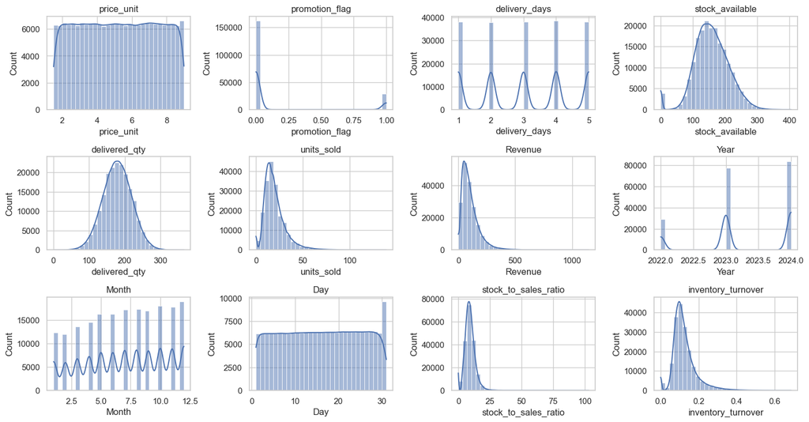

```python
# Distribution Plots for Numerical Columns
numerical_cols = df.select_dtypes(include = np.number).columns

plt.figure(figsize = (15,10))
for i, col in enumerate(numerical_cols):
    plt.subplot(4, 4, i+1) # Adjust grid layout as needed
    sns.histplot(df[col], kde = True, bins =30)
    plt.title(col)
plt.tight_layout()
plt.show()
```

### 5. Outlier Detection

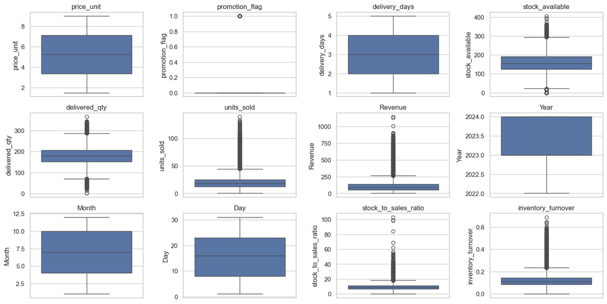

```python
# Outlier Detection with Boxplots
plt.figure(figsize = (15,10))
for i, col in enumerate(numerical_cols):
    plt.subplot(4, 4, i+1)
    sns.boxplot(y = df[col])
    plt.title(col)
plt.tight_layout()
plt.show()
```

## **Interpretation and Conclusion**

## Delivery Days:-

1. Mean (Average):
   - The average delivery time is 3 days
   - This indicates that most deliveries are completed around 3 days
2. Minimum = 1 day:
   - The fastest delivery recorded is 1 day, showing that quick delivery is possible in some cases.
3. Maximum = 5 days:
   - The slowest delivery takes 5 days, indicating that delays are limited and controlled.
4. Range (1 to 5 days):
   - Delivery times vary within a narrow and reasonable range, suggesting consistency in the delivery process.
5. Variance = 2.001:
   - The variance shows a moderate spread of delivery days around the mean.
   - This implies that delivery times are not highly scattered.
6. Standard Deviation = 1.414 days:
   - On average, delivery times differ from the mean by about 1.4 days.
   - Most deliveries occur between 2 to 4 days (mean ± standard deviation).

**Overall Interpretation:**

- The delivery system is fairly stable and predictable.
- Occasional early or late deliveries exist, but extreme delays are absent.

## Price Unit:-

1. Mean = 5.252:
   - The average price per unit is approximately 5.25.
2. Minimum = 1.5:
   - The lowest recorded unit price is 1.5 dollars.
   - This indicates the presence of low-priced or budget items.
3. Maximum = 9:
   - The highest unit price is 9 dollars.
   - This shows that some products are priced significantly higher than average.
4. Range (1.5 to 9):
   - The price values span a wide range, suggesting price diversity across products.
5. Standard Deviation = 2.167:
   - On average, unit prices deviate from the mean by about 2.17 units.
   - Most prices are likely to fall between 3.1 and 7.4 (mean ± standard deviation).
6. Variance = 4.695:
   - The variance indicates a moderate level of dispersion in unit prices.
   - Prices are not tightly clustered, but also not extremely scattered.

**Overall Interpretation**

- The Price_Unit data shows moderate variability, reflecting a mix of low-, mid-, and high-priced products.
- This pricing structure suggests product variety and flexible pricing strategy within the dataset.

## Stock Available:-

1. Mean = 157.70 units:
   - On average, about 158 units of stock are available.
2. Minimum = 0 units:
   - The minimum stock level is 0, indicating that stock-out situations occur for some items.
   - This may lead to lost sales or unmet demand.
3. Maximum = 405 units:
   - The maximum stock available is 405 units.
   - This suggests that some products are heavily stocked, possibly high-demand items or overstocked goods.
4. Range (0 to 405 units):
   - The stock levels show a very wide range, indicating significant variation in inventory across products.
5. Standard Deviation = 52.73 units:
   - On average, stock levels deviate from the mean by about 53 units.
   - Most products have stock levels roughly between 105 and 210 units (mean ± standard deviation).
6. Variance = 2780.72:
   - The high variance indicates a large dispersion in stock availability.
   - Inventory levels are highly inconsistent across different items.

**Overall Interpretation**

- The stock availability data shows high variability, with both stock-outs and overstocking present.
- This suggests a need for better inventory planning and demand forecasting.

## Delivered Quantity:-

1. Mean = 179.34 units:
   - On average, about 179 units are delivered per observation.
   - This represents the typical delivery quantity.
2. Minimum = 1 unit:
   - The minimum delivered quantity is 1 unit, indicating very small or partial deliveries in some cases.
3. Maximum = 366 units:
   - The maximum delivered quantity is 366 units.
   - This suggests that some deliveries are large-volume shipments.
4. Range (1 to 366 units):
   - The delivered quantities span a wide range, showing variation in order sizes.
5. Standard Deviation = 40.03 units:
   - On average, delivered quantities differ from the mean by about 40 units.
   - Most deliveries fall roughly between 139 and 219 units (mean ± standard deviation).
6. Variance = 1602.48:
   - The variance indicates a considerable dispersion in delivered quantities.

**Overall Interpretation**

- The delivered quantity shows moderate to high variability, reflecting a mix of small and large deliveries.
- This suggests flexible delivery patterns depending on demand or order size.

## Units Sold:-

1. Mean = 19.92 units:
   - On average, about 20 units are sold per observation.
   - This represents the typical sales volume.
2. Minimum = 0 units:
   - The minimum value is 0, indicating that no sales occurred in some cases.
   - This may point to low demand, stock unavailability, or inactive periods.
3. Maximum = 139 units:
   - The maximum number of units sold is 139.
   - This shows that some observations experience very high sales, possibly due to promotions or high demand.
4. Range (0 to 139 units):
   - The wide range suggests large variation in sales volume across observations.
5. Standard Deviation = 11.77 units:
   - On average, sales differ from the mean by about 11.77 units.
   - Most sales values lie approximately between 8 and 32 units (mean ± standard deviation).
6. Variance = 138.52:
   - The variance indicates a moderate level of dispersion in units sold.
   - Sales volumes are not consistent across all observations.

**Overall Interpretation**

- The units_sold data shows noticeable variability, with periods of no sales and occasional high sales.
- This reflects fluctuating demand patterns across products or time periods.

## Revenue:-

1. Mean = 104.59:
   - On average, the revenue generated per observation is about 104.6 Dollars.
   - This represents the typical revenue level in the dataset.
2. Minimum = 0:
   - The minimum revenue is 0, indicating that no revenue was generated in some cases.
   - This may be due to zero sales, stock-outs, or inactive periods.
3. Maximum = 1145.6:
   - The maximum revenue recorded is 1145.6 Dollars, which is much higher than the average.
   - This suggests the presence of very high-revenue transactions or outliers.
4. Range (0 to 1145.6):
   - The revenue values span a very wide range, indicating large differences in revenue generation.
5. Standard Deviation = 79.52:
   - On average, revenue deviates from the mean by about 79.5 Dollars.
   - Most revenue values are likely to fall roughly between 25 and 184 Dollars (mean ± standard deviation).
6. Variance = 6323.81:
   - The high variance indicates substantial dispersion in revenue values.
   - Revenue is highly inconsistent across observations.

**Overall Interpretation**

- The revenue data shows high variability, with many low-revenue observations and a few very high-revenue cases.
- This suggests uneven sales performance, possibly driven by product mix, demand fluctuations, or promotions.

## Overall Conclusion of Descriptive Analysis

- The dataset shows a well-structured operational system with reasonably controlled delivery times, moderate pricing variability, and significant differences in inventory, sales, and revenue performance.
- Delivery Days are fairly consistent, with an average of 3 days and a narrow range (1–5 days). This indicates a stable and predictable delivery process, with no extreme delays.
- Price_Unit exhibits moderate variability, suggesting a mix of low-, mid-, and high-priced products. The pricing strategy appears flexible, allowing the business to cater to different customer segments.
- Stock_Available shows high variability, ranging from 0 to 405 units. The presence of both stock-outs and overstocking highlights inefficiencies in inventory management and indicates a need for better demand forecasting and stock control.
- Delivered Quantity varies moderately to highly, reflecting different order sizes and demand levels. This suggests that the supply chain is flexible, adjusting delivery quantities based on requirements.
- Units_Sold displays noticeable fluctuations, with some periods of no sales and some of very high sales. This points to uneven demand patterns, possibly influenced by promotions, seasonality, or product popularity.
- Revenue shows high dispersion, with many low-revenue observations and a few very high-revenue transactions. This indicates uneven sales performance, where revenue is heavily driven by specific products or high-volume sales events.

# *Final Business Insight:*

**Overall, the analysis reveals a stable delivery system and flexible pricing structure, but highlights significant variability in inventory levels, sales volume, and revenue generation. Improving inventory planning, demand forecasting, and sales strategy could help reduce inconsistencies and enhance overall business performance.**

# **Objective 1: Sales Performance Analysis**

### 1. Time-Based Sales Analysis

#### (I) Year-wise Sales Trend

```python
Year_Frequency = df.Year.value_counts().div(1_000).round(2).astype(str) + 'K'
Year_Frequency
```

```
Year
2024    83.96K
2023    77.55K
2022    29.25K
Name: count, dtype: object
```

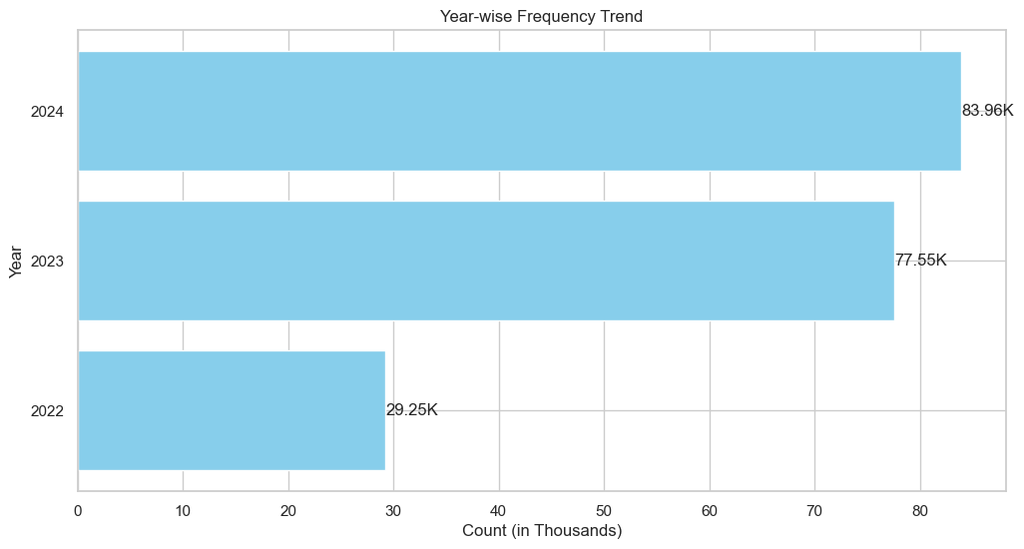

```python
import matplotlib.pyplot as plt

# Year frequency
Year_Frequency = df['Year'].value_counts().div(1_000).round(2)

# Sort for better visualization
Year_Frequency = Year_Frequency.sort_values()

# Plot
plt.figure()
plt.barh(Year_Frequency.index.astype(str), Year_Frequency.values, color='skyblue')

plt.title("Year-wise Frequency Trend")
plt.xlabel("Count (in Thousands)")
plt.ylabel("Year")

# Show values on bars
for i, v in enumerate(Year_Frequency.values):
    plt.text(v, i, f"{v}K", va='center')

plt.show()
```

#### (II) Month-wise Sales Trend

```python
Month_Frequency = df.Month.value_counts().sort_index().div(1_000).round(1).astype(str) + 'K'
Month_Frequency
```

```
Month
1     12.3K
2     11.9K
3     13.5K
4     14.5K
5     16.2K
6     16.2K
7     17.1K
8     17.3K
9     17.0K
10    18.0K
11    17.8K
12    18.9K
Name: count, dtype: object
```

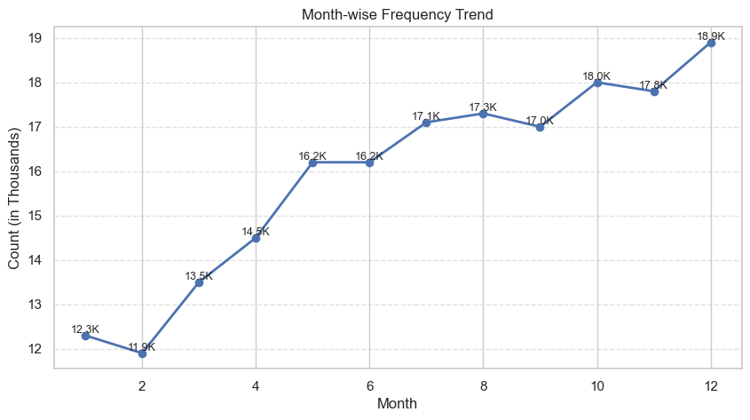

```python
import matplotlib.pyplot as plt

# Month frequency
Month_Frequency = df['Month'].value_counts().sort_index().div(1_000).round(1)

plt.figure(figsize=(10,5))

# Line plot with markers
plt.plot(
    Month_Frequency.index,
    Month_Frequency.values,
    marker='o',
    linewidth=2
)

plt.title("Month-wise Frequency Trend")
plt.xlabel("Month")
plt.ylabel("Count (in Thousands)")

# Grid for better readability
plt.grid(axis='y', linestyle='--', alpha=0.6)

# Value labels
for x, y in zip(Month_Frequency.index, Month_Frequency.values):
    plt.text(x, y, f"{y}K", ha='center', va='bottom', fontsize=9)

plt.show()
```

#### (III) Day-wise Sales Pattern

```python
Day_Frequency = df.Day.value_counts().sort_index().div(1_000).round(1).astype(str) + 'K'
Day_Frequency
```

```
Day
1     6.1K
2     6.1K
3     6.1K
4     6.2K
5     6.1K
6     6.2K
7     6.2K
8     6.1K
9     6.2K
10    6.2K
11    6.2K
12    6.2K
13    6.3K
14    6.3K
```

[output cut: 18 more lines]

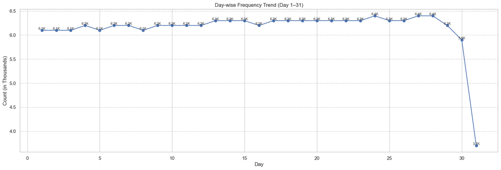

```python
Day_Frequency = df.Day.value_counts().sort_index().div(1_000).round(1)

plt.figure(figsize=(20,6))

plt.plot(
    Day_Frequency.index,
    Day_Frequency.values,
    marker='o'
)

plt.grid(axis='y', linestyle='--', alpha=0.9)
plt.title("Day-wise Frequency Trend (Day 1–31)")
plt.xlabel("Day")
plt.ylabel("Count (in Thousands)")

# Value labels
for x, y in zip(Day_Frequency.index, Day_Frequency.values):
    plt.text(x, y, f"{y}K", ha='center', va='bottom', fontsize=8)

plt.show()
```

### 2. Sales Distribution Across Dimensions

#### (I) Region-wise Sales Distribution

```python
df.groupby('region')['units_sold'].sum().sort_values(ascending=False).div(1_000_000).round(3).astype(str) + 'M'
```

```
region
PL-North       1.27M
PL-South      1.268M
PL-Central    1.262M
Name: units_sold, dtype: object
```

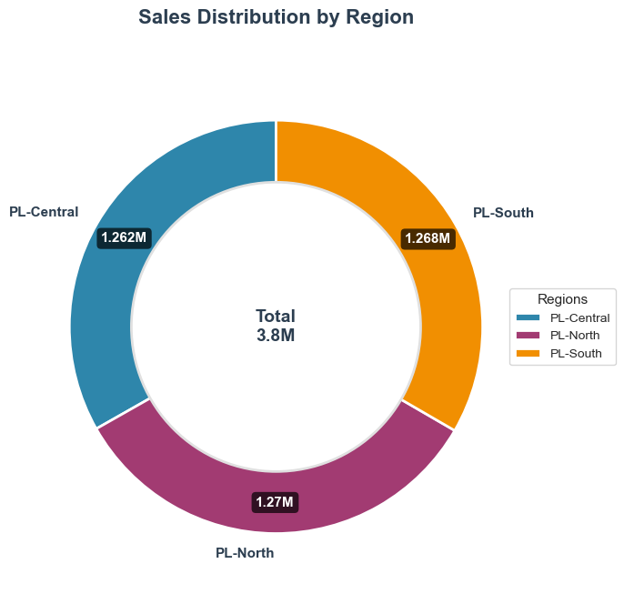

```python
import matplotlib.pyplot as plt
import numpy as np

# Data already prepared
sales_by_region = (df.groupby('region')['units_sold'].sum().div(1_000_000).round(3))

# Professional color palette
colors = ['#2E86AB', '#A23B72', '#F18F01', '#C73E1D', '#6A994E']
# Alternative professional palettes:
# colors = ['#264653', '#2A9D8F', '#E9C46A', '#F4A261', '#E76F51']
# colors = ['#1B3B4F', '#2A5F6E', '#4C8577', '#B5B682', '#F4D58C']

plt.figure(figsize=(7, 7))

# Create donut chart with enhanced styling
wedges, texts, autotexts = plt.pie(
    sales_by_region.values,
    labels=sales_by_region.index,
    autopct=lambda pct: f"{round(pct/100.*sales_by_region.sum(), 3)}M",
    startangle=90,
    colors=colors[:len(sales_by_region)],
    wedgeprops={'edgecolor': 'white', 'linewidth': 2, 'antialiased': True},
    textprops={'fontsize': 12, 'fontweight': 'bold'},
    pctdistance=0.85,
    labeldistance=1.1
)

# Style the percentage text inside the donut
for autotext in autotexts:
    autotext.set_color('white')
    autotext.set_fontsize(11)
    autotext.set_fontweight('bold')
    autotext.set_bbox(dict(boxstyle='round,pad=0.3', facecolor='black', alpha=0.7, edgecolor='none'))

# Style the region labels outside the donut
for text in texts:
    text.set_color('#2C3E50')
    text.set_fontsize(11)
    text.set_fontweight('semibold')

# Draw center circle (donut hole) with optional inner text
centre_circle = plt.Circle((0, 0), 0.70, fc='white', edgecolor='#E0E0E0', linewidth=2)
fig = plt.gcf()
fig.gca().add_artist(centre_circle)

# Add total sales in the center
total_sales = sales_by_region.sum()
plt.text(0, 0, f'Total\n{total_sales:.1f}M',
         ha='center', va='center',
         fontsize=14, fontweight='bold',
         color='#2C3E50')

# Add title and styling
plt.title('Sales Distribution by Region',
          fontsize=16, fontweight='bold',
          pad=20, color='#2C3E50')

# Add subtle shadow effect
for wedge in wedges:
    wedge.set_edgecolor('white')
    wedge.set_linewidth(2)

# Equal aspect ratio ensures the pie is circular
plt.axis('equal')

# Add legend
plt.legend(wedges, sales_by_region.index,
           title="Regions",
           loc="center left",
           bbox_to_anchor=(1, 0, 0.5, 1),
           fontsize=10,
           title_fontsize=11)

plt.tight_layout()
plt.show()
```

#### (II) Channel-wise Sales Distribution

```python
df.groupby('channel')['units_sold'].sum().sort_values(ascending=False).div(1_000_000).round(3).astype(str) + 'M'
```

```
channel
E-commerce    1.269M
Retail        1.267M
Discount      1.264M
Name: units_sold, dtype: object
```

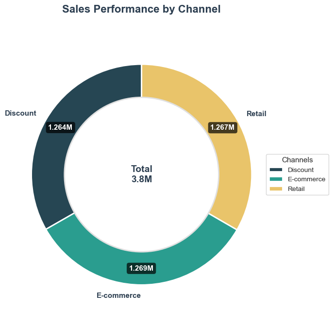

```python
import matplotlib.pyplot as plt
import numpy as np

# Data already prepared
sales_by_channel = (df.groupby('channel')['units_sold'].sum().div(1_000_000).round(3))

# Map colors based on available channels
colors = ['#264653', '#2A9D8F', '#E9C46A']

plt.figure(figsize=(7, 7))

# Create donut chart with enhanced styling
wedges, texts, autotexts = plt.pie(
    sales_by_channel.values,
    labels=sales_by_channel.index,
    autopct=lambda pct: f"{round(pct/100.*sales_by_channel.sum(), 3)}M",
    startangle=90,
    colors=colors,
    wedgeprops={'edgecolor': 'white', 'linewidth': 2, 'antialiased': True},
    textprops={'fontsize': 12, 'fontweight': 'bold'},
    pctdistance=0.85,
    labeldistance=1.1
)

# Style the percentage text inside the donut
for autotext in autotexts:
    autotext.set_color('white')
    autotext.set_fontsize(11)
    autotext.set_fontweight('bold')
    autotext.set_bbox(dict(boxstyle='round,pad=0.3', facecolor='black', alpha=0.7, edgecolor='none'))

# Style the channel labels outside the donut
for text in texts:
    text.set_color('#2C3E50')
    text.set_fontsize(11)
    text.set_fontweight('semibold')

# Draw center circle (donut hole) with styling
centre_circle = plt.Circle((0, 0), 0.70, fc='white', edgecolor='#E0E0E0', linewidth=2)
fig = plt.gcf()
fig.gca().add_artist(centre_circle)

# Add total sales in the center
total_sales = sales_by_channel.sum()
plt.text(0, 0, f'Total\n{total_sales:.1f}M',
         ha='center', va='center',
         fontsize=14, fontweight='bold',
         color='#2C3E50')

# Add title with professional styling
plt.title('Sales Performance by Channel',
          fontsize=16, fontweight='bold',
          pad=20, color='#2C3E50')

# Add subtle shadow effect
for wedge in wedges:
    wedge.set_edgecolor('white')
    wedge.set_linewidth(2)

# Equal aspect ratio ensures the pie is circular
plt.axis('equal')

# Add legend
plt.legend(wedges, sales_by_channel.index,
           title="Channels",
           loc="center left",
           bbox_to_anchor=(1, 0, 0.5, 1),
           fontsize=10,
           title_fontsize=11)

plt.tight_layout()
plt.show()
```

#### (III) Pack Type Analysis

```python
df.groupby('pack_type')['units_sold'].sum().sort_values(ascending=False).div(1_000_000).round(3).astype(str) + 'M'
```

```
pack_type
Single        1.27M
Carton       1.267M
Multipack    1.263M
Name: units_sold, dtype: object
```

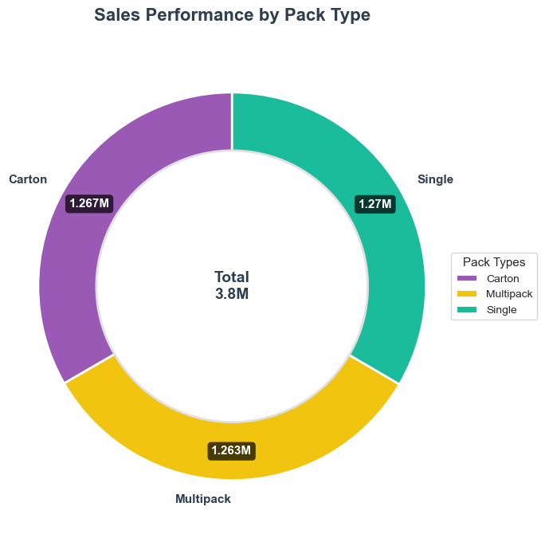

```python
import matplotlib.pyplot as plt
import numpy as np

# Numeric values in millions
pack_sales = (df.groupby('pack_type')['units_sold'].sum().div(1_000_000))

# Option 6: Sunset Palette
colors = ['#9B59B6', '#F1C40F', '#1ABC9C']

plt.figure(figsize=(7, 7))

# Create donut chart with enhanced styling
wedges, texts, autotexts = plt.pie(
    pack_sales.values,
    labels=pack_sales.index,
    autopct=lambda pct: f"{round((pct/100)*pack_sales.sum(), 3)}M",
    startangle=90,
    colors=colors[:len(pack_sales)],
    wedgeprops={'edgecolor': 'white', 'linewidth': 2, 'antialiased': True},
    textprops={'fontsize': 12, 'fontweight': 'bold'},
    pctdistance=0.85,
    labeldistance=1.1
)

# Style the percentage text inside the donut
for autotext in autotexts:
    autotext.set_color('white')
    autotext.set_fontsize(11)
    autotext.set_fontweight('bold')
    autotext.set_bbox(dict(boxstyle='round,pad=0.3', facecolor='black', alpha=0.7, edgecolor='none'))

# Style the pack type labels outside the donut
for text in texts:
    text.set_color('#2C3E50')
    text.set_fontsize(11)
    text.set_fontweight('semibold')

# Draw center circle (donut hole) with styling
centre_circle = plt.Circle((0, 0), 0.70, fc='white', edgecolor='#E0E0E0', linewidth=2)
fig = plt.gcf()
fig.gca().add_artist(centre_circle)

# Add total sales in the center
total_sales = pack_sales.sum()
plt.text(0, 0, f'Total\n{total_sales:.1f}M',
         ha='center', va='center',
         fontsize=14, fontweight='bold',
         color='#2C3E50')

# Add title with professional styling
plt.title('Sales Performance by Pack Type',
          fontsize=16, fontweight='bold',
          pad=20, color='#2C3E50')

# Add subtle shadow effect
for wedge in wedges:
    wedge.set_edgecolor('white')
    wedge.set_linewidth(2)

# Equal aspect ratio ensures the pie is circular
plt.axis('equal')

# Add legend
plt.legend(wedges, pack_sales.index,
           title="Pack Types",
           loc="center left",
           bbox_to_anchor=(1, 0, 0.5, 1),
           fontsize=10,
           title_fontsize=11)

plt.tight_layout()
plt.show()
```

### 3. Product-Level Analysis

#### (I) Category-wise Sales

```python
# in numbers
df.groupby('category')['units_sold'].sum().sort_values(ascending=False).div(1_000).round(1).astype(str) + 'K'
```

```
category
Yogurt       1566.6K
Milk          782.7K
ReadyMeal     678.8K
SnackBar      647.4K
Juice         124.3K
Name: units_sold, dtype: object
```

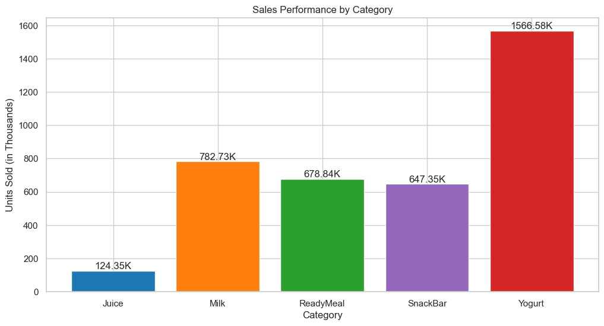

```python
# Numeric values in Thousand (for plotting)
sales_by_category = (df.groupby('category')['units_sold'].sum().div(1_000).round(2))

#Plot
plt.figure()
plt.bar(sales_by_category.index,sales_by_category.values,color = ['#1F77B4', '#FF7F0E', '#2CA02C', '#9467BD', '#D62728'])
plt.title('Sales Performance by Category')
plt.xlabel('Category')
plt.ylabel('Units Sold (in Thousands)')

# Add value labels with 'K'
for i,v in enumerate(sales_by_category.values):
    plt.text(i, v, f"{v}K", ha = 'center', va = 'bottom')

plt.show()
```

#### (II) Brand-wise Sales

```python
df.groupby('brand')['units_sold'].sum().sort_values(ascending=False).div(1_000).round(1).astype(str) + 'K'
```

```
brand
SnBrand2    543.9K
YoBrand4    471.9K
YoBrand3    401.5K
YoBrand2    385.5K
MiBrand3    317.6K
YoBrand1    307.7K
ReBrand4    291.2K
ReBrand2    238.0K
MiBrand1    217.2K
MiBrand4    152.3K
ReBrand1    149.6K
JuBrand3    124.3K
SnBrand3    103.4K
MiBrand2     95.5K
Name: units_sold, dtype: object
```

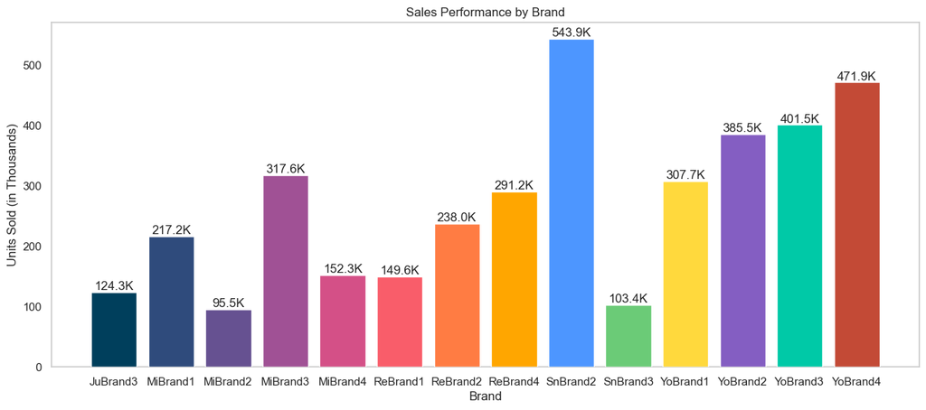

```python
# Numeric values in Thousand (for plotting )

sales_by_brand = (df.groupby('brand')['units_sold'].sum().div(1_000).round(1))

# Plot
plt.figure(figsize = (15,6))
plt.bar(sales_by_brand.index,sales_by_brand.values,zorder=3, color = [
    '#003f5c', '#2f4b7c', '#665191', '#a05195',
    '#d45087', '#f95d6a', '#ff7c43', '#ffa600',
    '#4D96FF', '#6BCB77', '#FFD93D', '#845EC2',
    '#00C9A7', '#C34A36'
])
plt.title('Sales Performance by Brand')
plt.xlabel('Brand')
plt.ylabel('Units Sold (in Thousands)')
plt.grid()

# Add value labels with 'K'
for i,v in enumerate(sales_by_brand.values):
    plt.text(i, v, f"{v}K", ha = 'center', va = 'bottom')

plt.show()
```

### 4. Contribution Analysis

#### (I) Category Contribution (%)

```python
# Total units sold
total_units_sold = df['units_sold'].sum()

# Category-wise units sold contribution
category_contribution = (
    df.groupby('category')['units_sold'].sum() / total_units_sold * 100
).sort_values(ascending=False)

# Add % sign
category_contribution_percent = category_contribution.round(2).astype(str) + '%'

print(category_contribution_percent)
```

```
category
Yogurt       41.23%
Milk          20.6%
ReadyMeal    17.86%
SnackBar     17.04%
Juice         3.27%
Name: units_sold, dtype: object
```

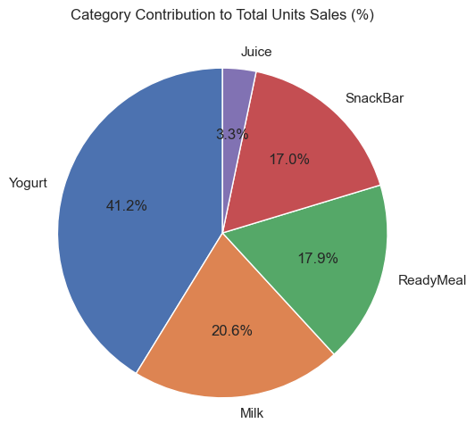

```python
plt.figure()

plt.pie(
    category_contribution.values,
    labels=category_contribution.index,
    autopct='%1.1f%%',
    startangle=90
)

plt.title("Category Contribution to Total Units Sales (%)")
plt.show()
```

#### (II) Brand Contribution (%)

```python
# Total units sold
total_units = df['units_sold'].sum()

# Contribution calculation
brand_contribution = (
    df.groupby('brand')['units_sold']
    .sum()
    .sort_values(ascending=False)
    .div(total_units)
    .mul(100)
    .round(2)
    .astype(str) + '%'
)

brand_contribution
```

```
brand
SnBrand2    14.31%
YoBrand4    12.42%
YoBrand3    10.57%
YoBrand2    10.14%
MiBrand3     8.36%
YoBrand1      8.1%
ReBrand4     7.66%
ReBrand2     6.26%
MiBrand1     5.72%
MiBrand4     4.01%
ReBrand1     3.94%
JuBrand3     3.27%
SnBrand3     2.72%
MiBrand2     2.51%
Name: units_sold, dtype: object
```

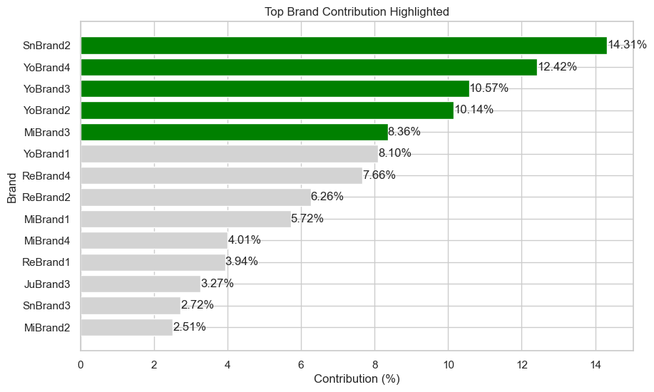

```python
import matplotlib.pyplot as plt

# Calculate contribution (numeric)
total_units = df['units_sold'].sum()

brand_contribution = (
    df.groupby('brand')['units_sold']
    .sum()
    .sort_values(ascending=True)   # ascending for horizontal bar
    / total_units * 100
)

# Create colors (highlight top 5)
colors = ['green' if i >= len(brand_contribution)-5 else 'lightgray'
          for i in range(len(brand_contribution))]

# Plot
plt.figure(figsize=(10,6))
plt.barh(brand_contribution.index, brand_contribution.values, color=colors)

plt.title("Top Brand Contribution Highlighted")
plt.xlabel("Contribution (%)")
plt.ylabel("Brand")

# Value labels
for i, v in enumerate(brand_contribution.values):
    plt.text(v, i, f"{v:.2f}%", va='center')

plt.show()
```